# Table Manipulation

E. Le Pennec

Fall 2019

The goal of this lab is to use **R** to manipulate tables. We will use both the *tidyverse* way with **dplyr** and the **SQL** way. We will also learn how to import data from various sources.

We will focus on a fake human resource database made of 7 tables. They have been generated by Harry Hallas on his website http://harry.ahlas.com.

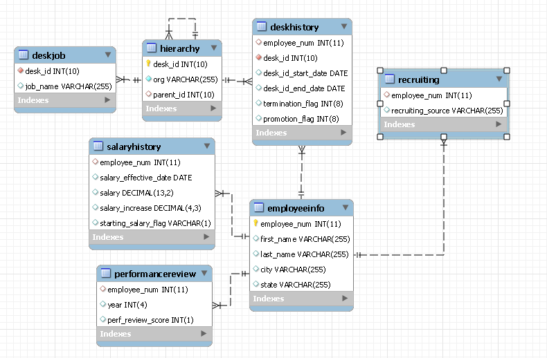

# Table manipulation

We will try to answer the following questions:

1. What is the maximum salary?
2. Who was paid this salary?
3. What was the corresponding position?
4. What is the average salary of this position?
5. What is the average salary by position?
6. What are the top 10 average salaries?

## The *tidyverse* way

In this first section, we will assume we already have the corresponding tables in **R**, we will focus later on the import part. In order to have those tables in your session, a file containing them is provided:

```r
load("tbls.RData")
```

Note that the file should be in your working directory.

If you are using **RStudio** as suggested, you should see the 7 tables in the Environment panel.

We are going to use the *tidyverse*, a opinionated collection of packages, to deal with the tables. The functions available in a package can be made available by loading the package with the **library** function.

```r
library(tidyverse)
```

Note that you should first install any package you want to used. This has to be done only once using **install.packages** or the packages panel in **RStudio**.

**dplyr** is a package loaded by **tidyverse** that contains a lot of function to handle tables in **R**. For instance,

- one can look at the structure of a table

```r
glimpse(deskhistory_tbl)
```

```
## Observations: 10,360
## Variables: 6
## $ employee_num       <int> 16684, 29068, 19507, 7504, 2549, 8869, 21041,…
## $ desk_id            <int> 1, 2, 3, 4, 5, 6, 7, 8, 9, 10, 11, 12, 13, 14…
## $ desk_id_start_date <date> 1999-01-01, 1999-01-01, 1999-01-01, 1999-01-…
## $ desk_id_end_date   <date> 2999-01-01, 2002-10-01, 2003-07-04, 2002-04-…
## $ termination_flag   <int> 0, 0, 0, 0, 0, 0, 1, 0, 0, 0, 0, 0, 0, 0, 0, …
## $ promotion_flag     <int> 0, 0, 0, 0, 0, 0, 0, 0, 0, 0, 0, 0, 0, 0, 0, …
```

- filter a table with a condition

```r
filter(salaryhistory_tbl,
       salary_effective_date >= lubridate::dmy("01-01-2000"),
       salary_effective_date <= lubridate::dmy("31-12-2000"))
```

```
## # A tibble: 1,278 x 5
##    employee_num salary_effective_… salary salary_increase starting_salary_…
##           <int> <date>              <dbl>           <dbl> <chr>
##  1         6773 2000-03-01         6.51e5           0.055 N
##  2         8878 2000-03-01         5.75e5           0.047 N
##  3        41637 2000-03-01         5.98e5           0.062 N
##  4        17198 2000-03-01         6.23e5           0.043 N
##  5        21103 2000-03-01         5.68e5           0.049 N
##  6        14721 2000-03-01         6.27e5           0.059 N
##  7        12427 2000-03-01         6.45e5           0.049 N
##  8        44398 2000-03-01         6.65e5           0.056 N
##  9        36559 2000-03-01         6.41e5           0.046 N
## 10         8204 2000-03-01         5.80e5           0.048 N
## # … with 1,268 more rows
```

where we have use the **pkg::fct** notation to call the function **fct** from the package **pkg** without making all the functions of **pkg** available. - select a few column

```r
select(salaryhistory_tbl,
       employee_num, salary)
```

```
## # A tibble: 25,617 x 2
##    employee_num  salary
##           <int>   <dbl>
##  1         6773 617400
##  2         6773 651357
##  3         6773 671549.
##  4         6773 699754.
##  5         6773 717248.
##  6         8878 549600
##  7         8878 575431.
##  8         8878 586940.
##  9         8878 603961.
## 10         8878 619060.
## # … with 25,607 more rows
```

- create a new column

```r
mutate(salaryhistory_tbl,
       salary_effective_year = lubridate::year(salary_effective_date))
```

```
## # A tibble: 25,617 x 6
##    employee_num salary_effectiv… salary salary_increase starting_salary…
##           <int> <date>            <dbl>           <dbl> <chr>
##  1         6773 1999-01-01       6.17e5           0     Y
##  2         6773 2000-03-01       6.51e5           0.055 N
##  3         6773 2001-03-01       6.72e5           0.031 N
##  4         6773 2002-03-01       7.00e5           0.042 N
##  5         6773 2003-03-01       7.17e5           0.025 N
##  6         8878 1999-01-01       5.50e5           0     Y
##  7         8878 2000-03-01       5.75e5           0.047 N
##  8         8878 2001-03-01       5.87e5           0.02  N
##  9         8878 2002-03-01       6.04e5           0.029 N
## 10         8878 2003-03-01       6.19e5           0.025 N
## # … with 25,607 more rows, and 1 more variable:
## #   salary_effective_year <dbl>
```

Note that the table **salaryhistory_tbl** is not modified, a new table has been created which should be explicitly saved

```r
salaryhistorymod_tbl <- mutate(salaryhistory_tbl,
       salary_effective_year = lubridate::year(salary_effective_date))
```

- summarize

```r
salaryhistorymod_tbl %>%
  filter(salary_effective_year == 2013) %>%
  summarize(salary = mean(salary))
```

```
## # A tibble: 1 x 1
##    salary
##     <dbl>
## 1 142578.
```

where we have used the R pipe %>% which allows to chain instructions. The previous sequence is equivalent to

```r
summarize(filter(salaryhistorymod_tbl, salary_effective_year == 2013), salary = mean(salary))
```

```
## # A tibble: 1 x 1
##    salary
##     <dbl>
## 1 142578.
```

or

```r
tmp <- salaryhistorymod_tbl
tmp <- filter(tmp, salary_effective_year == 2013)
summarize(tmp, salary = mean(salary))
```

```
## # A tibble: 1 x 1
##    salary
##     <dbl>
## 1 142578.
```

- use a group by strategy

```r
salaryhistorymod_tbl %>%
  group_by(salary_effective_year) %>%
  summarize(mean_salary = mean(salary))
```

```
## # A tibble: 20 x 2
##    salary_effective_year mean_salary
##                    <dbl>       <dbl>
##  1                  1999     114555.
##  2                  2000     120401.
##  3                  2001     124229.
##  4                  2002     125199.
##  5                  2003     127978.
##  6                  2004     129870.
##  7                  2005     130516.
##  8                  2006     133686.
##  9                  2007     138167.
## 10                  2008     141005.
## 11                  2009     140763.
## 12                  2010     141535.
## 13                  2011     140403.
## 14                  2012     140122.
## 15                  2013     142578.
## 16                  2014     144113.
## 17                  2015     141881.
## 18                  2016     133982.
## 19                  2017     135256.
## 20                  2018     144274.
```

- join two tables

```r
deskjob_tbl %>% left_join(hierarchy_tbl)
```

```
## # A tibble: 1,233 x 4
##    desk_id job_name        org             parent_id
##      <int> <chr>           <chr>               <int>
##  1       1 CEO             CEO                    NA
##  2       2 Business Leader Finance                 1
##  3       3 Business Leader Human Resources         1
##  4       4 Business Leader Sales                   1
##  5       5 Business Leader Marketing               1
##  6       6 Business Leader Legal                   1
##  7       7 Business Leader Technology              1
##  8       8 Business Leader Strategy                1
##  9       9 Business Leader Operations              1
## 10      10 Business Leader Compliance              1
## # … with 1,223 more rows
```

Note that the key used to join the table has been chosen automatically as the common column. It can be specified explicitly if required:

```r
deskjob_tbl %>% left_join(hierarchy_tbl, by = c("desk_id" = "desk_id"))
```

```
## # A tibble: 1,233 x 4
##    desk_id job_name        org             parent_id
##      <int> <chr>           <chr>               <int>
##  1       1 CEO             CEO                    NA
##  2       2 Business Leader Finance                 1
##  3       3 Business Leader Human Resources         1
##  4       4 Business Leader Sales                   1
##  5       5 Business Leader Marketing               1
##  6       6 Business Leader Legal                   1
##  7       7 Business Leader Technology              1
##  8       8 Business Leader Strategy                1
##  9       9 Business Leader Operations              1
## 10      10 Business Leader Compliance              1
## # … with 1,223 more rows
```

More functions are available has shown in the Data transformation cheat sheet.

We are now almost ready to answer the questions we have. We will first define some alias for our tables

```r
deskhistory <- deskhistory_tbl
deskjob <- deskjob_tbl
employeeinfo <- employeeinfo_tbl
hierarchy <- hierarchy_tbl
performancereview <- performancereview_tbl
recruiting <- recruiting_tbl
salaryhistory <- salaryhistory_tbl
```

1. What is the maximum salary?

```r
max_salary <- salaryhistory %>%
  summarize(max_salary = max(salary))
max_salary
```

```
## # A tibble: 1 x 1
##   max_salary
##        <dbl>
## 1   1882292.
```

2. Who was paid this salary?

```r
who_max_salary <- salaryhistory %>%
  top_n(1, salary) %>%
  left_join(employeeinfo) %>%
  select(first_name, last_name, everything())
who_max_salary
```

```
## # A tibble: 1 x 9
##   first_name last_name employee_num salary_effectiv… salary salary_increase
##   <chr>      <chr>            <int> <date>            <dbl>           <dbl>
## 1 Makala     Niimi            14721 2015-03-01       1.88e6           0.034
## # … with 3 more variables: starting_salary_flag <chr>, city <chr>,
## #   state <chr>
```

```r
salaryhistory %>%
  inner_join(max_salary, by = c("salary" = "max_salary")) %>%
  left_join(employeeinfo) %>%
  select(first_name, last_name, everything())
```

```
## # A tibble: 1 x 9
##   first_name last_name employee_num salary_effectiv… salary salary_increase
##   <chr>      <chr>            <int> <date>            <dbl>           <dbl>
## 1 Makala     Niimi            14721 2015-03-01       1.88e6           0.034
## # … with 3 more variables: starting_salary_flag <chr>, city <chr>,
## #   state <chr>
```

3. What was the corresponding position?

```r
position_max_salary <- who_max_salary %>%
  left_join(deskhistory) %>%
  filter(salary_effective_date >= desk_id_start_date,
         salary_effective_date < desk_id_end_date) %>%
  left_join(deskjob) %>%
  left_join(hierarchy) %>%
  select(job_name, org, first_name, last_name, everything())
position_max_salary
```

```
## # A tibble: 1 x 17
##   job_name org   first_name last_name employee_num salary_effectiv… salary
##   <chr>    <chr> <chr>      <chr>            <int> <date>            <dbl>
## 1 Busines… Huma… Makala     Niimi            14721 2015-03-01       1.88e6
## # … with 10 more variables: salary_increase <dbl>,
## #   starting_salary_flag <chr>, city <chr>, state <chr>, desk_id <int>,
## #   desk_id_start_date <date>, desk_id_end_date <date>,
## #   termination_flag <int>, promotion_flag <int>, parent_id <int>
```

4. What is the average salary of this position?

```r
position_average_salary <- position_max_salary %>%
  select(desk_id) %>%
  left_join(deskhistory) %>%
  left_join(salaryhistory) %>%
  filter(salary_effective_date >= desk_id_start_date,
         salary_effective_date < desk_id_end_date) %>%
  summarize(mean_salary = mean(salary))
position_average_salary
```

```
## # A tibble: 1 x 1
##   mean_salary
##         <dbl>
## 1    1192520.
```

5. What is the average salary by position?

```r
average_salary <- deskjob %>%
  left_join(hierarchy) %>%
  left_join(deskhistory) %>%
  left_join(salaryhistory) %>%
  filter(salary_effective_date >= desk_id_start_date,
         salary_effective_date < desk_id_end_date) %>%
  group_by(desk_id, job_name, org) %>%
  summarize(mean_salary = mean(salary)) %>%
  ungroup()
average_salary
```

```
## # A tibble: 1,226 x 4
##    desk_id job_name          org                              mean_salary
##      <int> <chr>             <chr>                                  <dbl>
##  1       3 Business Leader   Human Resources                     1192520.
##  2       4 Business Leader   Sales                               1253863.
##  3      10 Business Leader   Compliance                           872173.
##  4      11 Department Leader Fnnc - Accounting                    752993.
##  5      12 Department Leader Fnnc - Financial Planning            714722.
##  6      13 Department Leader Fnnc - Control                       616803.
##  7      14 Department Leader Fnnc - Audit                         510338.
##  8      15 Department Leader Hmn Rsrcs - HR Analytics             675953.
##  9      16 Department Leader Hmn Rsrcs - Employee Relations       635536.
## 10      17 Department Leader Hmn Rsrcs - Employee Development     668932.
## # … with 1,216 more rows
```

6. What are the top 10 average salaries?

```r
average_salary_top10 <- average_salary %>%
  top_n(10, mean_salary) %>%
  arrange(desc(mean_salary))
average_salary_top10
```

```
## # A tibble: 10 x 4
##    desk_id job_name        org                                  mean_salary
##      <int> <chr>           <chr>                                      <dbl>
##  1       4 Business Leader Sales                                   1253863.
##  2       3 Business Leader Human Resources                         1192520.
##  3      10 Business Leader Compliance                               872173.
##  4      29 Department Lea… Lgl - Product                            867383.
##  5      30 Department Lea… Lgl - Worker Compensation                853710.
##  6      47 Department Lea… Oprtns - Innovation                      817773.
##  7      31 Department Lea… Lgl - Intellectual Property              762104.
##  8      11 Department Lea… Fnnc - Accounting                        752993.
##  9      20 Department Lea… Mrktng - Marketing and Information …     739921.
## 10      39 Department Lea… Tchnlgy - Data Science                   737736.
```

```r
average_salary %>%
  filter(rank(desc(mean_salary))<=10) %>%
  arrange(desc(mean_salary))
```

```
## # A tibble: 10 x 4
##    desk_id job_name        org                                  mean_salary
##      <int> <chr>           <chr>                                      <dbl>
##  1       4 Business Leader Sales                                   1253863.
##  2       3 Business Leader Human Resources                         1192520.
##  3      10 Business Leader Compliance                               872173.
##  4      29 Department Lea… Lgl - Product                            867383.
##  5      30 Department Lea… Lgl - Worker Compensation                853710.
##  6      47 Department Lea… Oprtns - Innovation                      817773.
##  7      31 Department Lea… Lgl - Intellectual Property              762104.
##  8      11 Department Lea… Fnnc - Accounting                        752993.
##  9      20 Department Lea… Mrktng - Marketing and Information …     739921.
## 10      39 Department Lea… Tchnlgy - Data Science                   737736.
```

```r
average_salary %>%
  arrange(desc(mean_salary)) %>%
  head(10)
```

```
## # A tibble: 10 x 4
##    desk_id job_name        org                                  mean_salary
##      <int> <chr>           <chr>                                      <dbl>
##  1       4 Business Leader Sales                                   1253863.
##  2       3 Business Leader Human Resources                         1192520.
##  3      10 Business Leader Compliance                               872173.
##  4      29 Department Lea… Lgl - Product                            867383.
##  5      30 Department Lea… Lgl - Worker Compensation                853710.
##  6      47 Department Lea… Oprtns - Innovation                      817773.
##  7      31 Department Lea… Lgl - Intellectual Property              762104.
##  8      11 Department Lea… Fnnc - Accounting                        752993.
##  9      20 Department Lea… Mrktng - Marketing and Information …     739921.
## 10      39 Department Lea… Tchnlgy - Data Science                   737736.
```

## The **SQL** way

We are now going to use a SQL database to work with the tables. We are going to use **MonetDB** a not well known database which can be used without a system installation. Note that the **R** package has been discontinued (but a replacement called **duckdb** is in progress). To install it, we will use the CRAN Time Machine:

```r
if (!("MonetDBLite" %in% installed.packages())) {
  install.packages("MonetDBLite",
                   repos = "https://cran.microsoft.com/snapshot/2019-04-01/")
}
```

You should download the *hrsample_db.zip* and decompress it in your working directory. The *hrsample_db* directory contains all the table in the MonetDB format. We can connect to this database from **R** with:

```r
library(DBI)
conn <- dbConnect(MonetDBLite::MonetDBLite(),
                  "hrsample_db")
```

Note that both **DBI** and **MonetDBLite** should be installed.

We can check that all the tables are available using

```r
dbListTables(conn)
```

```
## [1] "deskhistory"       "deskjob"           "employeeinfo"
## [4] "hierarchy"         "performancereview" "recruiting"
## [7] "salaryhistory"
```

If this is not the case, you can either try to check whether *hrsample_db* is in the right directory or recreate the database from scratch with

```r
dbWriteTable(conn, "deskhistory", deskhistory_tbl)
dbWriteTable(conn, "deskjob", deskjob_tbl)
dbWriteTable(conn, "employeeinfo", employeeinfo_tbl)
dbWriteTable(conn, "hierarchy", hierarchy_tbl)
dbWriteTable(conn, "performancereview", performancereview_tbl)
dbWriteTable(conn, "recruiting", recruiting_tbl)
dbWriteTable(conn, "salaryhistory", salaryhistory_tbl)
```

One can now use **dbGetQuery** to send SQL queries to the database

```r
dbGetQuery(conn,
           "SELECT * FROM deskjob LIMIT 10")
```

```
##    desk_id        job_name
## 1        1             CEO
## 2        2 Business Leader
## 3        3 Business Leader
## 4        4 Business Leader
## 5        5 Business Leader
## 6        6 Business Leader
## 7        7 Business Leader
## 8        8 Business Leader
## 9        9 Business Leader
## 10      10 Business Leader
```

Can you answer the questions using SQL?

1. What is the maximum salary?

```r
dbGetQuery(conn, 'SELECT MAX("salary") AS "max_salary"
FROM "salaryhistory"')
```

```
##   max_salary
## 1    1882292
```

2. Who was paid this salary?

```r
dbGetQuery(conn,
           'WITH max_salary AS (SELECT * FROM (SELECT *, RANK() OVER (ORDER BY "salary" DESC) AS rank
           FROM "salaryhistory") AS TBL WHERE rank = 1)
           SELECT first_name, last_name, max_salary.employee_num AS employee_num
           , salary_effective_date,
           salary, salary_increase, starting_salary_flag, rank,
           city, state
           FROM "max_salary" LEFT JOIN "employeeinfo" ON
           (max_salary."employee_num" = employeeinfo."employee_num")
           ')
```

```
##   first_name last_name employee_num salary_effective_date  salary
## 1     Makala     Niimi        14721            2015-03-01 1882292
##   salary_increase starting_salary_flag rank          city state
## 1           0.034                    N    1 Michigan City    IN
```

```r
dbGetQuery(conn,
           'WITH max_salary AS  (SELECT * FROM (SELECT MAX(salary) AS maxsalary FROM salaryhistory) AS TBL
           JOIN salaryhistory ON (TBL.maxsalary = salaryhistory.salary))
           SELECT first_name, last_name, max_salary.employee_num AS employee_num
           , salary_effective_date,
           salary, salary_increase, starting_salary_flag,
           city, state
           FROM "max_salary" LEFT JOIN "employeeinfo" ON
           (max_salary."employee_num" = employeeinfo."employee_num")
           '
           )
```

```
##   first_name last_name employee_num salary_effective_date  salary
## 1     Makala     Niimi        14721            2015-03-01 1882292
##   salary_increase starting_salary_flag          city state
## 1           0.034                    N Michigan City    IN
```

3. What was the corresponding position?

```r
dbGetQuery(conn,
           'WITH max_salary AS (SELECT * FROM (SELECT MAX(salary) AS maxsalary FROM salaryhistory) AS TBL
           JOIN salaryhistory ON (TBL.maxsalary = salaryhistory.salary)),
           who_max_salary AS (SELECT first_name, last_name, max_salary.employee_num AS employee_num
           , salary_effective_date,
           salary, salary_increase, starting_salary_flag,
           city, state
           FROM "max_salary" LEFT JOIN "employeeinfo" ON
           (max_salary."employee_num" = employeeinfo."employee_num")),
           who_max_salary_join AS (SELECT * FROM who_max_salary
           LEFT JOIN deskhistory
           ON (who_max_salary.employee_num = deskhistory.employee_num)),
           who_max_salary_filter AS (SELECT * FROM who_max_salary_join
           WHERE ((salary_effective_date >= desk_id_start_date)
           AND (salary_effective_date < desk_id_end_date))),
           who_max_salary_join2 AS (SELECT * FROM who_max_salary_filter
           LEFT JOIN deskjob
           ON (who_max_salary_filter.desk_id = deskjob.desk_id))
           SELECT job_name, org, first_name, last_name,
           employee_num, salary_effective_date, salary,
           salary_increase, starting_salary_flag,
           city, state,
           hierarchy.desk_id AS desk_id,
           desk_id_start_date, desk_id_end_date,
           termination_flag, promotion_flag,
           parent_id
           FROM who_max_salary_join2
           LEFT JOIN hierarchy
           ON (who_max_salary_join2.desk_id = hierarchy.desk_id)
           ')
```

```
##          job_name             org first_name last_name employee_num
## 1 Business Leader Human Resources     Makala     Niimi        14721
##   salary_effective_date  salary salary_increase starting_salary_flag
## 1            2015-03-01 1882292           0.034                    N
##            city state desk_id desk_id_start_date desk_id_end_date
## 1 Michigan City    IN       3         2011-03-08       2015-12-18
##   termination_flag promotion_flag parent_id
## 1                1              1         1
```

4. What is the average salary of this position?

```r
dbGetQuery(conn,
           'WITH max_salary AS (SELECT * FROM (SELECT MAX(salary) AS maxsalary FROM salaryhistory) AS TBL
           JOIN salaryhistory ON (TBL.maxsalary = salaryhistory.salary)),
           who_max_salary AS (SELECT first_name, last_name, max_salary.employee_num AS employee_num
           , salary_effective_date,
           salary, salary_increase, starting_salary_flag,
           city, state
           FROM "max_salary" LEFT JOIN "employeeinfo" ON
           (max_salary."employee_num" = employeeinfo."employee_num")),
           who_max_salary_join AS (SELECT * FROM who_max_salary
           LEFT JOIN deskhistory
           ON (who_max_salary.employee_num = deskhistory.employee_num)),
           who_max_salary_filter AS (SELECT * FROM who_max_salary_join
           WHERE ((salary_effective_date >= desk_id_start_date)
           AND (salary_effective_date < desk_id_end_date))),
           who_max_salary_join2 AS (SELECT * FROM who_max_salary_filter
           LEFT JOIN deskjob
           ON (who_max_salary_filter.desk_id = deskjob.desk_id)),
           position_max_salary AS (SELECT
           hierarchy.desk_id AS desk_id
           FROM who_max_salary_join2
           LEFT JOIN hierarchy
           ON (who_max_salary_join2.desk_id = hierarchy.desk_id)),
           position_max_salary_join AS (SELECT * FROM position_max_salary
           LEFT JOIN deskhistory ON
           (position_max_salary.desk_id = deskhistory.desk_id)),
           position_max_salary_join2 AS (SELECT * FROM position_max_salary_join
           LEFT JOIN salaryhistory ON
           (position_max_salary_join.employee_num = salaryhistory.employee_num))
           SELECT AVG(salary) AS mean_salary FROM position_max_salary_join2
           WHERE ((salary_effective_date >= desk_id_start_date)
           AND (salary_effective_date < desk_id_end_date))
          ')
```

```
##   mean_salary
## 1     1192520
```

5. What is the average salary by position?

```r
dbGetQuery(conn,
           'WITH
           position_salary_join AS (SELECT * FROM deskhistory
           LEFT JOIN salaryhistory ON
           (deskhistory.employee_num = salaryhistory.employee_num)),
           position_mean_salary AS (SELECT desk_id, AVG(salary) AS mean_salary FROM position_salary_join
           WHERE ((salary_effective_date >= desk_id_start_date)
           AND (salary_effective_date < desk_id_end_date))
           GROUP BY desk_id),
           deskjob_hierarchy AS (SELECT * FROM deskjob LEFT JOIN hierarchy
           ON (deskjob.desk_id = hierarchy.desk_id))
           SELECT position_mean_salary.desk_id AS desk_id,
           job_name, org, mean_salary
           FROM position_mean_salary LEFT JOIN deskjob_hierarchy
           ON (position_mean_salary.desk_id = deskjob_hierarchy.desk_id)
           LIMIT 10
          ')
```

```
##    desk_id          job_name                              org mean_salary
## 1        3   Business Leader                  Human Resources   1192519.6
## 2        4   Business Leader                            Sales   1253863.1
## 3       10   Business Leader                       Compliance    872173.3
## 4       11 Department Leader                Fnnc - Accounting    752993.0
## 5       12 Department Leader        Fnnc - Financial Planning    714722.1
## 6       13 Department Leader                   Fnnc - Control    616802.5
## 7       14 Department Leader                     Fnnc - Audit    510338.0
## 8       15 Department Leader         Hmn Rsrcs - HR Analytics    675952.9
## 9       16 Department Leader   Hmn Rsrcs - Employee Relations    635535.6
## 10      17 Department Leader Hmn Rsrcs - Employee Development    668932.5
```

What happens if one remove the LIMIT?

6. What are the top 10 average salaries?

```r
dbGetQuery(conn,
           'WITH
           position_salary_join AS (SELECT * FROM deskhistory
           LEFT JOIN salaryhistory ON
           (deskhistory.employee_num = salaryhistory.employee_num)),
           position_mean_salary AS (SELECT desk_id, AVG(salary) AS mean_salary FROM position_salary_join
           WHERE ((salary_effective_date >= desk_id_start_date)
           AND (salary_effective_date < desk_id_end_date))
           GROUP BY desk_id),
           deskjob_hierarchy AS (SELECT * FROM deskjob LEFT JOIN hierarchy
           ON (deskjob.desk_id = hierarchy.desk_id)),
           position_mean_salary2 AS (SELECT * FROM (SELECT *, RANK() OVER (ORDER BY "mean_salary" DESC) AS rank
           FROM position_mean_salary) tbl
           WHERE (rank <= 10))
           SELECT position_mean_salary2.desk_id AS desk_id,
           job_name, org, mean_salary
           FROM position_mean_salary2 LEFT JOIN deskjob_hierarchy
           ON (position_mean_salary2.desk_id = deskjob_hierarchy.desk_id)
           ORDER BY mean_salary DESC
          ')
```

```
##    desk_id          job_name                                           org
## 1        4   Business Leader                                         Sales
## 2        3   Business Leader                               Human Resources
## 3       10   Business Leader                                    Compliance
## 4       29 Department Leader                                 Lgl - Product
## 5       30 Department Leader                     Lgl - Worker Compensation
## 6       47 Department Leader                           Oprtns - Innovation
## 7       31 Department Leader                   Lgl - Intellectual Property
## 8       11 Department Leader                             Fnnc - Accounting
## 9       20 Department Leader Mrktng - Marketing and Information Management
## 10      39 Department Leader                        Tchnlgy - Data Science
##    mean_salary
## 1    1253863.1
## 2    1192519.6
## 3     872173.3
## 4     867383.0
## 5     853710.1
## 6     817772.8
## 7     762104.3
## 8     752993.0
## 9     739921.4
## 10    737735.7
```

## The *dbplyr* way

**dplyr**, or rather **dbplyr**, allows to work directly on the distant tables. It suffices to make pointer to those tables:

```r
deskhistory_db <- tbl(conn, "deskhistory")
deskjob_db <- tbl(conn, "deskjob")
employeeinfo_db <- tbl(conn, "employeeinfo")
hierarchy_db <- tbl(conn, "hierarchy")
performancereview_db <- tbl(conn, "performancereview")
recruiting_db <- tbl(conn, "recruiting")
salaryhistory_db <- tbl(conn, "salaryhistory")
```

We can them work with them *as if* they were in memory:

```r
deskjob_db
```

```
## # Source:   table<deskjob> [?? x 2]
## # Database: MonetDBEmbeddedConnection
##    desk_id job_name
##      <int> <chr>
##  1       1 CEO
##  2       2 Business Leader
##  3       3 Business Leader
##  4       4 Business Leader
##  5       5 Business Leader
##  6       6 Business Leader
##  7       7 Business Leader
##  8       8 Business Leader
##  9       9 Business Leader
## 10      10 Business Leader
## # … with more rows
```

```r
salaryhistory_db %>% filter(salary >= 100000)
```

```
## # Source:   lazy query [?? x 5]
## # Database: MonetDBEmbeddedConnection
##    employee_num salary_effective_… salary salary_increase starting_salary_…
##           <int> <date>              <dbl>           <dbl> <chr>
##  1         6773 1999-01-01         6.17e5           0     Y
##  2         6773 2000-03-01         6.51e5           0.055 N
##  3         6773 2001-03-01         6.72e5           0.031 N
##  4         6773 2002-03-01         7.00e5           0.042 N
##  5         6773 2003-03-01         7.17e5           0.025 N
##  6         8878 1999-01-01         5.50e5           0     Y
##  7         8878 2000-03-01         5.75e5           0.047 N
##  8         8878 2001-03-01         5.87e5           0.02  N
##  9         8878 2002-03-01         6.04e5           0.029 N
## 10         8878 2003-03-01         6.19e5           0.025 N
## # … with more rows
```

Note that the computation are performed in the database and only a few records are retrieved in **R**. One should add **collect** to force a full retrieval as in

```r
salaryhistory_db %>%
  filter(salary >= 100000) %>%
  collect() %>%
  head(10)
```

```
## # A tibble: 10 x 5
##    employee_num salary_effective_… salary salary_increase starting_salary_…
##           <int> <date>              <dbl>           <dbl> <chr>
##  1         6773 1999-01-01         6.17e5           0     Y
##  2         6773 2000-03-01         6.51e5           0.055 N
##  3         6773 2001-03-01         6.72e5           0.031 N
##  4         6773 2002-03-01         7.00e5           0.042 N
##  5         6773 2003-03-01         7.17e5           0.025 N
##  6         8878 1999-01-01         5.50e5           0     Y
##  7         8878 2000-03-01         5.75e5           0.047 N
##  8         8878 2001-03-01         5.87e5           0.02  N
##  9         8878 2002-03-01         6.04e5           0.029 N
## 10         8878 2003-03-01         6.19e5           0.025 N
```

Redefining our alias, will help reuse the **dplyr** code

```r
deskhistory <- deskhistory_db
deskjob <- deskjob_db
employeeinfo <- employeeinfo_db
hierarchy <- hierarchy_db
performancereview <- performancereview_db
recruiting <- recruiting_db
salaryhistory <- salaryhistory_db
```

1. What is the maximum salary?

```r
max_salary <- salaryhistory %>%
  summarize(max_salary = max(salary))
max_salary %>% collect()
```

```
## # A tibble: 1 x 1
##   max_salary
##        <dbl>
## 1   1882292.
```

2. Who was paid this salary?

```r
who_max_salary <- salaryhistory %>%
  filter(rank(desc(salary)) == 1) %>%
  left_join(employeeinfo) %>%
  select(first_name, last_name, everything())
who_max_salary %>% collect()
```

```
## # A tibble: 1 x 9
##   first_name last_name employee_num salary_effectiv… salary salary_increase
##   <chr>      <chr>            <int> <date>            <dbl>           <dbl>
## 1 Makala     Niimi            14721 2015-03-01       1.88e6           0.034
## # … with 3 more variables: starting_salary_flag <chr>, city <chr>,
## #   state <chr>
```

3. What was the corresponding position?

```r
position_max_salary <- who_max_salary %>%
  left_join(deskhistory) %>%
  filter(salary_effective_date >= desk_id_start_date,
         salary_effective_date < desk_id_end_date) %>%
  left_join(deskjob) %>%
  left_join(hierarchy) %>%
  select(job_name, org, first_name, last_name, everything())
position_max_salary %>% collect()
```

```
## # A tibble: 1 x 17
##   job_name org   first_name last_name employee_num salary_effectiv… salary
##   <chr>    <chr> <chr>      <chr>            <int> <date>            <dbl>
## 1 Busines… Huma… Makala     Niimi            14721 2015-03-01       1.88e6
## # … with 10 more variables: salary_increase <dbl>,
## #   starting_salary_flag <chr>, city <chr>, state <chr>, desk_id <int>,
## #   desk_id_start_date <date>, desk_id_end_date <date>,
## #   termination_flag <int>, promotion_flag <int>, parent_id <int>
```

4. What is the average salary of this position?

```r
position_average_salary <- position_max_salary %>%
  select(desk_id) %>%
  left_join(deskhistory) %>%
  left_join(salaryhistory) %>%
  filter(salary_effective_date >= desk_id_start_date,
         salary_effective_date < desk_id_end_date) %>%
  summarize(mean_salary = mean(salary))
position_average_salary %>% collect()
```

```
## # A tibble: 1 x 1
##   mean_salary
##         <dbl>
## 1    1192520.
```

5. What is the average salary by position?

```r
average_salary <- deskjob %>%
  left_join(hierarchy) %>%
  left_join(deskhistory) %>%
  left_join(salaryhistory) %>%
  filter(salary_effective_date >= desk_id_start_date,
         salary_effective_date < desk_id_end_date) %>%
  group_by(desk_id, job_name, org) %>%
  summarize(mean_salary = mean(salary))
average_salary
```

```
## # Source:   lazy query [?? x 4]
## # Database: MonetDBEmbeddedConnection
## # Groups:   desk_id, job_name
##    desk_id job_name        org                                  mean_salary
##      <int> <chr>           <chr>                                      <dbl>
##  1      11 Department Lea… Fnnc - Accounting                        752993.
##  2      12 Department Lea… Fnnc - Financial Planning                714722.
##  3      13 Department Lea… Fnnc - Control                           616803.
##  4      14 Department Lea… Fnnc - Audit                             510338.
##  5      15 Department Lea… Hmn Rsrcs - HR Analytics                 675953.
##  6      16 Department Lea… Hmn Rsrcs - Employee Relations           635536.
##  7      17 Department Lea… Hmn Rsrcs - Employee Development         668932.
##  8      18 Department Lea… Hmn Rsrcs - HR Strategy                  707204.
##  9      19 Department Lea… Mrktng - Communications                  687334.
## 10      20 Department Lea… Mrktng - Marketing and Information …     739921.
## # … with more rows
```

Note that we do not use **collect** here on purpose…

6. What are the top 10 average salaries?

```r
average_salary_top10 <- average_salary %>%
  ungroup() %>%
  filter(rank(desc(mean_salary))<=10) %>%
  arrange(desc(mean_salary))
average_salary_top10 %>% collect()
```

```
## # A tibble: 10 x 4
##    desk_id job_name        org                                  mean_salary
##      <int> <chr>           <chr>                                      <dbl>
##  1       4 Business Leader Sales                                   1253863.
##  2       3 Business Leader Human Resources                         1192520.
##  3      10 Business Leader Compliance                               872173.
##  4      29 Department Lea… Lgl - Product                            867383.
##  5      30 Department Lea… Lgl - Worker Compensation                853710.
##  6      47 Department Lea… Oprtns - Innovation                      817773.
##  7      31 Department Lea… Lgl - Intellectual Property              762104.
##  8      11 Department Lea… Fnnc - Accounting                        752993.
##  9      20 Department Lea… Mrktng - Marketing and Information …     739921.
## 10      39 Department Lea… Tchnlgy - Data Science                   737736.
```

### How does **dbplyr** works?

In the previous examples, **dbplyr** is preparing a SQL request that is send to the database only when required. One can look at the request using **show_query**:

```r
salaryhistory_db %>% filter(salary >= 100000) %>%
  show_query()
```

```
## <SQL>
## SELECT *
## FROM "salaryhistory"
## WHERE ("salary" >= 100000.0)
```

The translation depends on the database used! In particular, some operators are available only in some database. For instance, **RANK** is not available in SQLite…

We can obtain **lazy** table directly from SQL query using **tbl** with **sql**:

```r
tbl(conn, sql("SELECT * FROM salaryhistory"))
```

```
## # Source:   SQL [?? x 5]
## # Database: MonetDBEmbeddedConnection
##    employee_num salary_effective_… salary salary_increase starting_salary_…
##           <int> <date>              <dbl>           <dbl> <chr>
##  1         6773 1999-01-01         6.17e5           0     Y
##  2         6773 2000-03-01         6.51e5           0.055 N
##  3         6773 2001-03-01         6.72e5           0.031 N
##  4         6773 2002-03-01         7.00e5           0.042 N
##  5         6773 2003-03-01         7.17e5           0.025 N
##  6         8878 1999-01-01         5.50e5           0     Y
##  7         8878 2000-03-01         5.75e5           0.047 N
##  8         8878 2001-03-01         5.87e5           0.02  N
##  9         8878 2002-03-01         6.04e5           0.029 N
## 10         8878 2003-03-01         6.19e5           0.025 N
## # … with more rows
```

Can you guess the SQL queries prepared by **dbplyr**?

```r
max_salary %>% show_query()
```

```
## <SQL>
## SELECT MAX("salary") AS "max_salary"
## FROM "salaryhistory"
```

```r
who_max_salary %>% show_query()
```

```
## <SQL>
## SELECT "first_name", "last_name", "employee_num", "salary_effective_date", "salary", "salary_increase", "starting_salary_flag", "city", "state"
## FROM (SELECT "LHS"."employee_num" AS "employee_num", "LHS"."salary_effective_date" AS "salary_effective_date", "LHS"."salary" AS "salary", "LHS"."salary_increase" AS "salary_increase", "LHS"."starting_salary_flag" AS "starting_salary_flag", "RHS"."first_name" AS "first_name", "RHS"."last_name" AS…
## FROM (SELECT "employee_num", "salary_effective_date", "salary", "salary_increase", "starting_salary_flag"
## FROM (SELECT "employee_num", "salary_effective_date", "salary", "salary_increase", "starting_salary_flag", RANK() OVER (ORDER BY "salary" DESC) AS "zzz13"
## FROM "salaryhistory") "dbplyr_018"
## WHERE ("zzz13" = 1.0)) "LHS"
## LEFT JOIN "employeeinfo" AS "RHS"
## ON ("LHS"."employee_num" = "RHS"."employee_num")
## ) "dbplyr_019"
```

```r
position_max_salary %>% show_query()
```

```
## <SQL>
## SELECT "job_name", "org", "first_name", "last_name", "employee_num", "salary_effective_date", "salary", "salary_increase", "starting_salary_flag", "city", "state", "desk_id", "desk_id_start_date", "desk_id_end_date", "termination_flag", "promotion_flag", "parent_id"
## FROM (SELECT "LHS"."first_name" AS "first_name", "LHS"."last_name" AS "last_name", "LHS"."employee_num" AS "employee_num", "LHS"."salary_effective_date" AS "salary_effective_date", "LHS"."salary" AS "salary", "LHS"."salary_increase" AS "salary_increase", "LHS"."starting_salary_flag" AS "starting_…
## FROM (SELECT "LHS"."first_name" AS "first_name", "LHS"."last_name" AS "last_name", "LHS"."employee_num" AS "employee_num", "LHS"."salary_effective_date" AS "salary_effective_date", "LHS"."salary" AS "salary", "LHS"."salary_increase" AS "salary_increase", "LHS"."starting_salary_flag" AS "starting_…
## FROM (SELECT *
## FROM (SELECT "LHS"."first_name" AS "first_name", "LHS"."last_name" AS "last_name", "LHS"."employee_num" AS "employee_num", "LHS"."salary_effective_date" AS "salary_effective_date", "LHS"."salary" AS "salary", "LHS"."salary_increase" AS "salary_increase", "LHS"."starting_salary_flag" AS "starting_…
## FROM (SELECT "first_name", "last_name", "employee_num", "salary_effective_date", "salary", "salary_increase", "starting_salary_flag", "city", "state"
## FROM (SELECT "LHS"."employee_num" AS "employee_num", "LHS"."salary_effective_date" AS "salary_effective_date", "LHS"."salary" AS "salary", "LHS"."salary_increase" AS "salary_increase", "LHS"."starting_salary_flag" AS "starting_salary_flag", "RHS"."first_name" AS "first_name", "RHS"."last_name" AS…
## FROM (SELECT "employee_num", "salary_effective_date", "salary", "salary_increase", "starting_salary_flag"
## FROM (SELECT "employee_num", "salary_effective_date", "salary", "salary_increase", "starting_salary_flag", RANK() OVER (ORDER BY "salary" DESC) AS "zzz14"
## FROM "salaryhistory") "dbplyr_020"
## WHERE ("zzz14" = 1.0)) "LHS"
## LEFT JOIN "employeeinfo" AS "RHS"
## ON ("LHS"."employee_num" = "RHS"."employee_num")
## ) "dbplyr_021") "LHS"
## LEFT JOIN "deskhistory" AS "RHS"
## ON ("LHS"."employee_num" = "RHS"."employee_num")
## ) "dbplyr_022"
## WHERE (("salary_effective_date" >= "desk_id_start_date") AND ("salary_effective_date" < "desk_id_end_date"))) "LHS"
## LEFT JOIN "deskjob" AS "RHS"
## ON ("LHS"."desk_id" = "RHS"."desk_id")
## ) "LHS"
## LEFT JOIN "hierarchy" AS "RHS"
## ON ("LHS"."desk_id" = "RHS"."desk_id")
## ) "dbplyr_023"
```

```r
position_average_salary %>% show_query()
```

```
## <SQL>
## SELECT AVG("salary") AS "mean_salary"
## FROM (SELECT "LHS"."desk_id" AS "desk_id", "LHS"."employee_num" AS "employee_num", "LHS"."desk_id_start_date" AS "desk_id_start_date", "LHS"."desk_id_end_date" AS "desk_id_end_date", "LHS"."termination_flag" AS "termination_flag", "LHS"."promotion_flag" AS "promotion_flag", "RHS"."salary_effectiv…
## FROM (SELECT "LHS"."desk_id" AS "desk_id", "RHS"."employee_num" AS "employee_num", "RHS"."desk_id_start_date" AS "desk_id_start_date", "RHS"."desk_id_end_date" AS "desk_id_end_date", "RHS"."termination_flag" AS "termination_flag", "RHS"."promotion_flag" AS "promotion_flag"
## FROM (SELECT "desk_id"
## FROM (SELECT "LHS"."first_name" AS "first_name", "LHS"."last_name" AS "last_name", "LHS"."employee_num" AS "employee_num", "LHS"."salary_effective_date" AS "salary_effective_date", "LHS"."salary" AS "salary", "LHS"."salary_increase" AS "salary_increase", "LHS"."starting_salary_flag" AS "starting_…
## FROM (SELECT "LHS"."first_name" AS "first_name", "LHS"."last_name" AS "last_name", "LHS"."employee_num" AS "employee_num", "LHS"."salary_effective_date" AS "salary_effective_date", "LHS"."salary" AS "salary", "LHS"."salary_increase" AS "salary_increase", "LHS"."starting_salary_flag" AS "starting_…
## FROM (SELECT *
## FROM (SELECT "LHS"."first_name" AS "first_name", "LHS"."last_name" AS "last_name", "LHS"."employee_num" AS "employee_num", "LHS"."salary_effective_date" AS "salary_effective_date", "LHS"."salary" AS "salary", "LHS"."salary_increase" AS "salary_increase", "LHS"."starting_salary_flag" AS "starting_…
## FROM (SELECT "first_name", "last_name", "employee_num", "salary_effective_date", "salary", "salary_increase", "starting_salary_flag", "city", "state"
## FROM (SELECT "LHS"."employee_num" AS "employee_num", "LHS"."salary_effective_date" AS "salary_effective_date", "LHS"."salary" AS "salary", "LHS"."salary_increase" AS "salary_increase", "LHS"."starting_salary_flag" AS "starting_salary_flag", "RHS"."first_name" AS "first_name", "RHS"."last_name" AS…
## FROM (SELECT "employee_num", "salary_effective_date", "salary", "salary_increase", "starting_salary_flag"
## FROM (SELECT "employee_num", "salary_effective_date", "salary", "salary_increase", "starting_salary_flag", RANK() OVER (ORDER BY "salary" DESC) AS "zzz15"
## FROM "salaryhistory") "dbplyr_024"
## WHERE ("zzz15" = 1.0)) "LHS"
## LEFT JOIN "employeeinfo" AS "RHS"
## ON ("LHS"."employee_num" = "RHS"."employee_num")
## ) "dbplyr_025") "LHS"
## LEFT JOIN "deskhistory" AS "RHS"
## ON ("LHS"."employee_num" = "RHS"."employee_num")
## ) "dbplyr_026"
## WHERE (("salary_effective_date" >= "desk_id_start_date") AND ("salary_effective_date" < "desk_id_end_date"))) "LHS"
## LEFT JOIN "deskjob" AS "RHS"
## ON ("LHS"."desk_id" = "RHS"."desk_id")
## ) "LHS"
## LEFT JOIN "hierarchy" AS "RHS"
## ON ("LHS"."desk_id" = "RHS"."desk_id")
## ) "dbplyr_027") "LHS"
## LEFT JOIN "deskhistory" AS "RHS"
## ON ("LHS"."desk_id" = "RHS"."desk_id")
## ) "LHS"
## LEFT JOIN "salaryhistory" AS "RHS"
## ON ("LHS"."employee_num" = "RHS"."employee_num")
## ) "dbplyr_028"
## WHERE (("salary_effective_date" >= "desk_id_start_date") AND ("salary_effective_date" < "desk_id_end_date"))
```

```r
average_salary %>% show_query()
```

```
## <SQL>
## SELECT "desk_id", "job_name", "org", AVG("salary") AS "mean_salary"
## FROM (SELECT "LHS"."desk_id" AS "desk_id", "LHS"."job_name" AS "job_name", "LHS"."org" AS "org", "LHS"."parent_id" AS "parent_id", "LHS"."employee_num" AS "employee_num", "LHS"."desk_id_start_date" AS "desk_id_start_date", "LHS"."desk_id_end_date" AS "desk_id_end_date", "LHS"."termination_flag" A…
## FROM (SELECT "LHS"."desk_id" AS "desk_id", "LHS"."job_name" AS "job_name", "LHS"."org" AS "org", "LHS"."parent_id" AS "parent_id", "RHS"."employee_num" AS "employee_num", "RHS"."desk_id_start_date" AS "desk_id_start_date", "RHS"."desk_id_end_date" AS "desk_id_end_date", "RHS"."termination_flag" A…
## FROM (SELECT "LHS"."desk_id" AS "desk_id", "LHS"."job_name" AS "job_name", "RHS"."org" AS "org", "RHS"."parent_id" AS "parent_id"
## FROM "deskjob" AS "LHS"
## LEFT JOIN "hierarchy" AS "RHS"
## ON ("LHS"."desk_id" = "RHS"."desk_id")
## ) "LHS"
## LEFT JOIN "deskhistory" AS "RHS"
## ON ("LHS"."desk_id" = "RHS"."desk_id")
## ) "LHS"
## LEFT JOIN "salaryhistory" AS "RHS"
## ON ("LHS"."employee_num" = "RHS"."employee_num")
## ) "dbplyr_029"
## WHERE (("salary_effective_date" >= "desk_id_start_date") AND ("salary_effective_date" < "desk_id_end_date"))
## GROUP BY "desk_id", "job_name", "org"
```

```r
average_salary_top10 %>% show_query()
```

```
## <SQL>
## SELECT "desk_id", "job_name", "org", "mean_salary"
## FROM (SELECT "desk_id", "job_name", "org", "mean_salary", RANK() OVER (ORDER BY "mean_salary" DESC) AS "zzz16"
## FROM (SELECT "desk_id", "job_name", "org", AVG("salary") AS "mean_salary"
## FROM (SELECT *
## FROM (SELECT "LHS"."desk_id" AS "desk_id", "LHS"."job_name" AS "job_name", "LHS"."org" AS "org", "LHS"."parent_id" AS "parent_id", "LHS"."employee_num" AS "employee_num", "LHS"."desk_id_start_date" AS "desk_id_start_date", "LHS"."desk_id_end_date" AS "desk_id_end_date", "LHS"."termination_flag" A…
## FROM (SELECT "LHS"."desk_id" AS "desk_id", "LHS"."job_name" AS "job_name", "LHS"."org" AS "org", "LHS"."parent_id" AS "parent_id", "RHS"."employee_num" AS "employee_num", "RHS"."desk_id_start_date" AS "desk_id_start_date", "RHS"."desk_id_end_date" AS "desk_id_end_date", "RHS"."termination_flag" A…
## FROM (SELECT "LHS"."desk_id" AS "desk_id", "LHS"."job_name" AS "job_name", "RHS"."org" AS "org", "RHS"."parent_id" AS "parent_id"
## FROM "deskjob" AS "LHS"
## LEFT JOIN "hierarchy" AS "RHS"
## ON ("LHS"."desk_id" = "RHS"."desk_id")
## ) "LHS"
## LEFT JOIN "deskhistory" AS "RHS"
## ON ("LHS"."desk_id" = "RHS"."desk_id")
## ) "LHS"
## LEFT JOIN "salaryhistory" AS "RHS"
## ON ("LHS"."employee_num" = "RHS"."employee_num")
## ) "dbplyr_030"
## WHERE (("salary_effective_date" >= "desk_id_start_date") AND ("salary_effective_date" < "desk_id_end_date"))) "dbplyr_031"
## GROUP BY "desk_id", "job_name", "org") "dbplyr_032") "dbplyr_033"
## WHERE ("zzz16" <= 10.0)
## ORDER BY "mean_salary" DESC
```

# Table import/export

We are now looking at some example to import (and export) tables in **R** from various sources.

## With CSV format

CSV (Comma Separated Values) is a classical file format to exchange data. It consists in text files in which the values are separated by a comma (or sometime another symbols). Often, the first line indicates the names of the columns. This is a simple format in which the column types are not specified and should be *guessed* by the reader.

In the *tidyverse*, the **readr** package proposes functions to read (and write) CSV files.

```r
write_csv(salaryhistory_tbl, "salaryhistory_test.csv")
salaryhistory_csv <- read_csv("salaryhistory_test.csv")
glimpse(salaryhistory_csv)
```

```
## Observations: 25,617
## Variables: 5
## $ employee_num          <dbl> 6773, 6773, 6773, 6773, 6773, 8878, 8878, …
## $ salary_effective_date <date> 1999-01-01, 2000-03-01, 2001-03-01, 2002-…
## $ salary                <dbl> 617400.0, 651357.0, 671549.1, 699754.1, 71…
## $ salary_increase       <dbl> 0.000, 0.055, 0.031, 0.042, 0.025, 0.000, …
## $ starting_salary_flag  <chr> "Y", "N", "N", "N", "N", "Y", "N", "N", "N…
```

Note that the column type may be slightly different than in the original table.

1. Read and correct the column type for the CSV files of the 7 tables.

```r
library(here)
```

```r
deskhistory_csv <- read_csv(here("deskhistory.csv"))
deskhistory_csv <- deskhistory_csv %>%
  mutate_at(vars(-ends_with("date")), as.integer)
deskjob_csv <- read_csv(here("deskjob.csv"))
deskjob_csv <- deskjob_csv %>%
  mutate_if(is.double, as.integer)
employeeinfo_csv <- read_csv(here("employeeinfo.csv"))
employeeinfo_csv <- employeeinfo_csv %>%
  mutate_if(is.double, as.integer)
hierarchy_csv  <- read_csv(here("hierarchy.csv"))
hierarchy_csv  <- hierarchy_csv  %>%
  mutate_if(is.double, as.integer)
performancereview_csv <- read_csv(here("performancereview.csv")) %>%
  mutate_if(is.double, as.integer)
recruiting_csv <- read_csv(here("recruiting.csv"),
                           col_types = cols(employee_num = col_integer(),
                                            recruiting_source = col_character()))
salaryhistory_csv <- read_csv(here("salaryhistory.csv"),
                              col_types = cols(employee_num = col_integer()))
```

What is the role of **here**?

2. Can you write them back?

```r
write_csv(deskhistory_tbl, here("deskhistory2.csv"))
write_csv(deskjob_tbl, here("deskjob2.csv"))
write_csv(employeeinfo_tbl, here("employeeinfo2.csv"))
write_csv(hierarchy_tbl, here("hierarchy2.csv"))
write_csv(performancereview_tbl, here("performancereview2.csv"))
write_csv(recruiting_tbl, here("recruiting2.csv"))
write_csv(salaryhistory_tbl, here("salaryhistory2.csv"))
```

## With xlsx format

1. Use **readxl** to read the data from the **hrsample.xlsx**.

```r
library(readxl)
deskhistory_xl <- read_xlsx(here("hrsample.xlsx"), "deskhistory")
deskhistory_xl <- deskhistory_xl %>%
  mutate_at(vars(-ends_with("date")), as.integer) %>%
  mutate_at(vars(ends_with("date")), as.Date)
deskjob_xl <- read_xlsx(here("hrsample.xlsx"), "deskjob")
deskjob_xl <- deskjob_xl %>%
  mutate_if(is.double, as.integer)
employeeinfo_xl <- read_xlsx(here("hrsample.xlsx"), "employeeinfo")
employeeinfo_xl <- employeeinfo_xl %>%
  mutate_if(is.double, as.integer)
hierarchy_xl <- read_xlsx(here("hrsample.xlsx"), "hierarchy")
hierarchy_xl <- hierarchy_xl %>%
  mutate_if(is.double, as.integer)
performancereview_xl <- read_xlsx(here("hrsample.xlsx"), "performancereview") %>%
  mutate_if(is.double, as.integer)
recruiting_xl <- read_xlsx(here("hrsample.xlsx"), "recruiting")
recruiting_xl <- recruiting_xl %>%
  mutate_if(is.double, as.integer)
salaryhistory_xl <- read_xlsx(here("hrsample.xlsx"), "salaryhistory")
salaryhistory_xl <- salaryhistory_xl %>%
  mutate_at("employee_num", as.integer) %>%
  mutate_at(vars(ends_with("date")), as.Date)
```

2. Use **writexl** to create an excel file.

```r
library(writexl)
write_xlsx(
  list(
    deskhistory = deskhistory_tbl,
    deskjob = deskjob_tbl,
    employeeinfo = employeeinfo_tbl,
    hierarchy = hierarchy_tbl,
    performancereview = performancereview_tbl,
    recruiting = recruiting_tbl,
    salaryhistory = salaryhistory_tbl
  ),
  "hrsample2.xlsx"
)
```

## With a database

1. Read the table from the database

```r
deskhistory_tbl2 <- tbl(conn, "deskhistory") %>% collect()
deskjob_tbl2 <- tbl(conn, "deskjob") %>% collect()
employeeinfo_tbl2 <- tbl(conn, "employeeinfo") %>% collect()
hierarchy_tbl2 <- tbl(conn, "hierarchy") %>% collect()
recruiting_tbl2 <- tbl(conn, "recruiting") %>% collect()
salaryhistory_tbl2 <- tbl(conn, "salaryhistory") %>% collect()
```

2. Write them back

```r
dbWriteTable(conn, "deskhistory", deskhistory_tbl)
```

```
## Error in .local(conn, name, value, ...): Table deskhistory already exists. Set overwrite=TRUE if you want
##       to remove the existing table. Set append=TRUE if you would like to add the new data to the
##       existing table.
```

```r
dbWriteTable(conn, "deskjob", deskjob_tbl)
```

```
## Error in .local(conn, name, value, ...): Table deskjob already exists. Set overwrite=TRUE if you want
##       to remove the existing table. Set append=TRUE if you would like to add the new data to the
##       existing table.
```

```r
dbWriteTable(conn, "employeeinfo", employeeinfo_tbl)
```

```
## Error in .local(conn, name, value, ...): Table employeeinfo already exists. Set overwrite=TRUE if you want
##       to remove the existing table. Set append=TRUE if you would like to add the new data to the
##       existing table.
```

```r
dbWriteTable(conn, "hierarchy", hierarchy_tbl)
```

```
## Error in .local(conn, name, value, ...): Table hierarchy already exists. Set overwrite=TRUE if you want
##       to remove the existing table. Set append=TRUE if you would like to add the new data to the
##       existing table.
```

```r
dbWriteTable(conn, "performancereview", performancereview_tbl)
```

```
## Error in .local(conn, name, value, ...): Table performancereview already exists. Set overwrite=TRUE if you want
##       to remove the existing table. Set append=TRUE if you would like to add the new data to the
##       existing table.
```

```r
dbWriteTable(conn, "recruiting", recruiting_tbl)
```

```
## Error in .local(conn, name, value, ...): Table recruiting already exists. Set overwrite=TRUE if you want
##       to remove the existing table. Set append=TRUE if you would like to add the new data to the
##       existing table.
```

```r
dbWriteTable(conn, "salaryhistory", salaryhistory_tbl)
```

```
## Error in .local(conn, name, value, ...): Table salaryhistory already exists. Set overwrite=TRUE if you want
##       to remove the existing table. Set append=TRUE if you would like to add the new data to the
##       existing table.
```

Why is there some errors?

## With another format

There are many different formats. For most of them, there is a function or a package available. For instance,

- **readRDS/saveRdS** for the native **R** format.
- **haven** for SPSS, Stata and SAS formats
- **feather** for the feather format…